# Data Visualisation with ggplot2 - Project

# Data Visualisation with ggplot2 - Project

## 1. Defining the Question

### a) Specifying the Data Analysis Question

Specify the reasearch question that you’ll be answering. i.e. Provide strategy recommendations that will lead to revenue growth.

### b) Defining the Metric for Success

The solutions to the following questions will help us answer our research question:

### c) Understanding the context

You are a Data Scientist working for Hilton International Hotels and need to help the management decide on the strategies that will lead to revenue growth. You have a dataset containing information on the various chain of hotels, including when customers made the booking, length of stay, the number of adults, children, or babies, and the number of available parking spaces, among other things. Given this dataset, perform data exploration, data cleaning, and analysis to come with appropriate recommendations.

### d) Recording the Experimental Design

The steps to be taken include:

1. Load dataset and preview its summarized information to get a feel of what you will be working with.
2. Carry out data cleaning.
3. Carry out data analysis.
4. Interpret results.
5. Provide recommendations based on results of analysis.
6. Challenge your solution.

### e) Data Relevance

How relevant was the provided data?

## 2. Data Cleaning and preparation.

### Installing packages

#### Let’s install tidyverse packages in Rstudio

```r
install.packages("tidyverse")
```

[output not shown]

#### Load tidyverse for use in our notebook

```r
library(tidyverse)
```

#### Read provided dataset into data frame and preview

```r
hotel_df <- read_csv("hotel_bookings.csv")
# check the first 5 rows of data
head(hotel_df, 5)
```

| hotel | is_canceled | lead_time | arrival_date_year | arrival_date_month | arrival_date_week_number | arrival_date_day_of_month | stays_in_weekend_nights | stays_in_week_nights | adults | children | babies | meal | country | market_segment | distribution_channel | is_repeated_guest | previous_cancellations | previous_bookings_not_canceled | reserved_room_type | assigned_room_type | booking_changes | deposit_type | agent | company | days_in_waiting_list | customer_type | adr | required_car_parking_spaces | total_of_special_requests | … |
| --- | --- | --- | --- | --- | --- | --- | --- | --- | --- | --- | --- | --- | --- | --- | --- | --- | --- | --- | --- | --- | --- | --- | --- | --- | --- | --- | --- | --- | --- | --- |
| Resort Hotel | 0 | 342 | 2015 | July | 27 | 1 | 0 | 0 | 2 | 0 | 0 | BB | PRT | Direct | Direct | 0 | 0 | 0 | C | C | 3 | No Deposit | NULL | NULL | 0 | Transient | 0 | 0 | 0 | … |
| Resort Hotel | 0 | 737 | 2015 | July | 27 | 1 | 0 | 0 | 2 | 0 | 0 | BB | PRT | Direct | Direct | 0 | 0 | 0 | C | C | 4 | No Deposit | NULL | NULL | 0 | Transient | 0 | 0 | 0 | … |
| Resort Hotel | 0 | 7 | 2015 | July | 27 | 1 | 0 | 1 | 1 | 0 | 0 | BB | GBR | Direct | Direct | 0 | 0 | 0 | A | C | 0 | No Deposit | NULL | NULL | 0 | Transient | 75 | 0 | 0 | … |
| Resort Hotel | 0 | 13 | 2015 | July | 27 | 1 | 0 | 1 | 1 | 0 | 0 | BB | GBR | Corporate | Corporate | 0 | 0 | 0 | A | A | 0 | No Deposit | 304 | NULL | 0 | Transient | 75 | 0 | 0 | … |
| Resort Hotel | 0 | 14 | 2015 | July | 27 | 1 | 0 | 2 | 2 | 0 | 0 | BB | GBR | Online TA | TA/TO | 0 | 0 | 0 | A | A | 0 | No Deposit | 240 | NULL | 0 | Transient | 98 | 0 | 1 | … |

```r
# check last 5 rows of data
tail(hotel_df, 5)
```

| hotel | is_canceled | lead_time | arrival_date_year | arrival_date_month | arrival_date_week_number | arrival_date_day_of_month | stays_in_weekend_nights | stays_in_week_nights | adults | children | babies | meal | country | market_segment | distribution_channel | is_repeated_guest | previous_cancellations | previous_bookings_not_canceled | reserved_room_type | assigned_room_type | booking_changes | deposit_type | agent | company | days_in_waiting_list | customer_type | adr | required_car_parking_spaces | total_of_special_requests | … |
| --- | --- | --- | --- | --- | --- | --- | --- | --- | --- | --- | --- | --- | --- | --- | --- | --- | --- | --- | --- | --- | --- | --- | --- | --- | --- | --- | --- | --- | --- | --- |
| City Hotel | 0 | 23 | 2017 | August | 35 | 30 | 2 | 5 | 2 | 0 | 0 | BB | BEL | Offline TA/TO | TA/TO | 0 | 0 | 0 | A | A | 0 | No Deposit | 394 | NULL | 0 | Transient | 96.14 | 0 | 0 | … |
| City Hotel | 0 | 102 | 2017 | August | 35 | 31 | 2 | 5 | 3 | 0 | 0 | BB | FRA | Online TA | TA/TO | 0 | 0 | 0 | E | E | 0 | No Deposit | 9 | NULL | 0 | Transient | 225.43 | 0 | 2 | … |
| City Hotel | 0 | 34 | 2017 | August | 35 | 31 | 2 | 5 | 2 | 0 | 0 | BB | DEU | Online TA | TA/TO | 0 | 0 | 0 | D | D | 0 | No Deposit | 9 | NULL | 0 | Transient | 157.71 | 0 | 4 | … |
| City Hotel | 0 | 109 | 2017 | August | 35 | 31 | 2 | 5 | 2 | 0 | 0 | BB | GBR | Online TA | TA/TO | 0 | 0 | 0 | A | A | 0 | No Deposit | 89 | NULL | 0 | Transient | 104.40 | 0 | 0 | … |
| City Hotel | 0 | 205 | 2017 | August | 35 | 29 | 2 | 7 | 2 | 0 | 0 | HB | DEU | Online TA | TA/TO | 0 | 0 | 0 | A | A | 0 | No Deposit | 9 | NULL | 0 | Transient | 151.20 | 0 | 2 | … |

```r
# Sample 10 rows of data
sample_n(hotel_df, 10)
```

| hotel | is_canceled | lead_time | arrival_date_year | arrival_date_month | arrival_date_week_number | arrival_date_day_of_month | stays_in_weekend_nights | stays_in_week_nights | adults | children | babies | meal | country | market_segment | distribution_channel | is_repeated_guest | previous_cancellations | previous_bookings_not_canceled | reserved_room_type | assigned_room_type | booking_changes | deposit_type | agent | company | days_in_waiting_list | customer_type | adr | required_car_parking_spaces | total_of_special_requests | … |
| --- | --- | --- | --- | --- | --- | --- | --- | --- | --- | --- | --- | --- | --- | --- | --- | --- | --- | --- | --- | --- | --- | --- | --- | --- | --- | --- | --- | --- | --- | --- |
| Resort Hotel | 0 | 58 | 2015 | September | 40 | 30 | 2 | 5 | 2 | 0 | 0 | BB | GBR | Online TA | TA/TO | 0 | 0 | 0 | A | A | 0 | No Deposit | 241 | NULL | 0 | Transient | 44.27 | 0 | 1 | … |
| City Hotel | 0 | 150 | 2016 | June | 23 | 4 | 2 | 2 | 2 | 0 | 0 | BB | CHE | Direct | Direct | 0 | 0 | 0 | D | D | 0 | No Deposit | 14 | NULL | 0 | Transient | 108.59 | 0 | 0 | … |
| City Hotel | 0 | 0 | 2016 | January | 4 | 20 | 0 | 1 | 1 | 0 | 0 | BB | CHN | Direct | TA/TO | 0 | 0 | 0 | A | A | 0 | No Deposit | NULL | NULL | 0 | Transient-Party | 89.00 | 0 | 0 | … |
| City Hotel | 0 | 34 | 2017 | August | 35 | 30 | 0 | 3 | 1 | 0 | 0 | BB | FRA | Corporate | Corporate | 1 | 1 | 5 | A | A | 0 | No Deposit | NULL | 91 | 0 | Transient | 85.00 | 0 | 0 | … |
| Resort Hotel | 0 | 58 | 2016 | November | 47 | 17 | 2 | 5 | 2 | 0 | 0 | HB | FRA | Offline TA/TO | TA/TO | 0 | 0 | 0 | A | D | 0 | No Deposit | 6 | NULL | 0 | Transient | 52.40 | 0 | 0 | … |
| City Hotel | 0 | 62 | 2015 | October | 41 | 8 | 0 | 3 | 1 | 0 | 0 | BB | PRT | Groups | TA/TO | 0 | 0 | 0 | A | A | 0 | No Deposit | 30 | NULL | 53 | Transient-Party | 65.45 | 0 | 0 | … |
| Resort Hotel | 0 | 80 | 2016 | October | 43 | 22 | 2 | 1 | 2 | 0 | 0 | BB | SWE | Groups | Corporate | 0 | 0 | 0 | G | G | 0 | No Deposit | NULL | NULL | 0 | Transient-Party | 115.00 | 1 | 0 | … |
| Resort Hotel | 0 | 0 | 2015 | November | 48 | 25 | 0 | 1 | 1 | 0 | 0 | BB | PRT | Online TA | TA/TO | 0 | 0 | 0 | D | D | 1 | No Deposit | 240 | NULL | 0 | Transient | 40.00 | 0 | 0 | … |
| City Hotel | 0 | 2 | 2016 | June | 27 | 26 | 2 | 3 | 2 | 0 | 0 | SC | PRT | Offline TA/TO | TA/TO | 0 | 0 | 0 | A | A | 0 | No Deposit | 28 | NULL | 0 | Transient | 63.75 | 0 | 0 | … |
| Resort Hotel | 1 | 40 | 2017 | February | 6 | 5 | 4 | 7 | 2 | 0 | 0 | BB | MOZ | Online TA | TA/TO | 0 | 0 | 0 | E | E | 0 | No Deposit | 240 | NULL | 0 | Transient | 68.00 | 0 | 1 | … |

```r
NA
```

```r
# Checking number of rows and columns
dim(hotel_df)
```

```
[1] 119390     32
```

```r
# Checking datatypes
str(hotel_df)
```

```
spc_tbl_ [119,390 × 32] (S3: spec_tbl_df/tbl_df/tbl/data.frame)
 $ hotel                         : chr [1:119390] "Resort Hotel" "Resort Hotel" "Resort Hotel" "Resort Hotel" ...
 $ is_canceled                   : num [1:119390] 0 0 0 0 0 0 0 0 1 1 ...
 $ lead_time                     : num [1:119390] 342 737 7 13 14 14 0 9 85 75 ...
 $ arrival_date_year             : num [1:119390] 2015 2015 2015 2015 2015 ...
 $ arrival_date_month            : chr [1:119390] "July" "July" "July" "July" ...
 $ arrival_date_week_number      : num [1:119390] 27 27 27 27 27 27 27 27 27 27 ...
 $ arrival_date_day_of_month     : num [1:119390] 1 1 1 1 1 1 1 1 1 1 ...
 $ stays_in_weekend_nights       : num [1:119390] 0 0 0 0 0 0 0 0 0 0 ...
 $ stays_in_week_nights          : num [1:119390] 0 0 1 1 2 2 2 2 3 3 ...
 $ adults                        : num [1:119390] 2 2 1 1 2 2 2 2 2 2 ...
 $ children                      : num [1:119390] 0 0 0 0 0 0 0 0 0 0 ...
 $ babies                        : num [1:119390] 0 0 0 0 0 0 0 0 0 0 ...
 $ meal                          : chr [1:119390] "BB" "BB" "BB" "BB" ...
 $ country                       : chr [1:119390] "PRT" "PRT" "GBR" "GBR" ...
 $ market_segment                : chr [1:119390] "Direct" "Direct" "Direct" "Corporate" ...
 $ distribution_channel          : chr [1:119390] "Direct" "Direct" "Direct" "Corporate" ...
 $ is_repeated_guest             : num [1:119390] 0 0 0 0 0 0 0 0 0 0 ...
 $ previous_cancellations        : num [1:119390] 0 0 0 0 0 0 0 0 0 0 ...
 $ previous_bookings_not_canceled: num [1:119390] 0 0 0 0 0 0 0 0 0 0 ...
 $ reserved_room_type            : chr [1:119390] "C" "C" "A" "A" ...
 $ assigned_room_type            : chr [1:119390] "C" "C" "C" "A" ...
 $ booking_changes               : num [1:119390] 3 4 0 0 0 0 0 0 0 0 ...
 $ deposit_type                  : chr [1:119390] "No Deposit" "No Deposit" "No Deposit" "No Deposit" ...
 $ agent                         : chr [1:119390] "NULL" "NULL" "NULL" "304" ...
 $ company                       : chr [1:119390] "NULL" "NULL" "NULL" "NULL" ...
 $ days_in_waiting_list          : num [1:119390] 0 0 0 0 0 0 0 0 0 0 ...
 $ customer_type                 : chr [1:119390] "Transient" "Transient" "Transient" "Transient" ...
 $ adr                           : num [1:119390] 0 0 75 75 98 ...
 $ required_car_parking_spaces   : num [1:119390] 0 0 0 0 0 0 0 0 0 0 ...
 $ total_of_special_requests     : num [1:119390] 0 0 0 0 1 1 0 1 1 0 ...
 $ reservation_status            : chr [1:119390] "Check-Out" "Check-Out" "Check-Out" "Check-Out" ...
 $ reservation_status_date       : Date[1:119390], format: "2015-07-01" ...
 - attr(*, "spec")=
  .. cols(
  ..   hotel = col_character(),
  ..   is_canceled = col_double(),
  ..   lead_time = col_double(),
  ..   arrival_date_year = col_double(),
  ..   arrival_date_month = col_character(),
```

[output cut: 14 more lines]

```
  ..   reserved_room_type = col_character(),
  ..   assigned_room_type = col_character(),
  ..   booking_changes = col_double(),
  ..   deposit_type = col_character(),
  ..   agent = col_character(),
  ..   company = col_character(),
  ..   days_in_waiting_list = col_double(),
  ..   customer_type = col_character(),
  ..   adr = col_double(),
  ..   required_car_parking_spaces = col_double(),
  ..   total_of_special_requests = col_double(),
  ..   reservation_status = col_character(),
  ..   reservation_status_date = col_date(format = "")
  .. )
 - attr(*, "problems")=<externalptr>
```

## 3. External Data Source Validation

The data is originally from the article Hotel Booking Demand Datasets, by Nuno Antonio, Ana Almeida, and Luis Nunes for Data in Brief, Volume 22, February 2019.

## 4. Data Preparation

### Performing Data Cleaning

```r
# Checking datatypes and missing entries of all the variables

colSums(is.na(hotel_df))
```

```
                         hotel
                             0
                   is_canceled
                             0
                     lead_time
                             0
             arrival_date_year
                             0
            arrival_date_month
                             0
      arrival_date_week_number
                             0
     arrival_date_day_of_month
                             0
       stays_in_weekend_nights
                             0
          stays_in_week_nights
                             0
                        adults
                             0
                      children
                             4
                        babies
                             0
                          meal
                             0
                       country
                             0
                market_segment
                             0
          distribution_channel
                             0
             is_repeated_guest
                             0
        previous_cancellations
                             0
previous_bookings_not_canceled
                             0
            reserved_room_type
                             0
```

[output cut: 9 more lines]

```
                             0
          days_in_waiting_list
                             0
                 customer_type
                             0
                           adr
                             0
   required_car_parking_spaces
                             0
     total_of_special_requests
                             0
            reservation_status
                             0
       reservation_status_date
                             0
```

4 missing values for variable ‘children’

```r
# Checking how many duplicate rows are there in the data

hotel_df[duplicated(hotel_df), ]
```

| hotel | is_canceled | lead_time | arrival_date_year | arrival_date_month | arrival_date_week_number | arrival_date_day_of_month | stays_in_weekend_nights | stays_in_week_nights | adults | children | babies | meal | country | market_segment | distribution_channel | is_repeated_guest | previous_cancellations | previous_bookings_not_canceled | reserved_room_type | assigned_room_type | booking_changes | deposit_type | agent | company | days_in_waiting_list | customer_type | adr | required_car_parking_spaces | total_of_special_requests | … |
| --- | --- | --- | --- | --- | --- | --- | --- | --- | --- | --- | --- | --- | --- | --- | --- | --- | --- | --- | --- | --- | --- | --- | --- | --- | --- | --- | --- | --- | --- | --- |
| Resort Hotel | 0 | 14 | 2015 | July | 27 | 1 | 0 | 2 | 2 | 0 | 0 | BB | GBR | Online TA | TA/TO | 0 | 0 | 0 | A | A | 0 | No Deposit | 240 | NULL | 0 | Transient | 98.00 | 0 | 1 | … |
| Resort Hotel | 0 | 72 | 2015 | July | 27 | 1 | 2 | 4 | 2 | 0 | 0 | BB | PRT | Direct | Direct | 0 | 0 | 0 | A | A | 1 | No Deposit | 250 | NULL | 0 | Transient | 84.67 | 0 | 1 | … |
| Resort Hotel | 0 | 70 | 2015 | July | 27 | 2 | 2 | 3 | 2 | 0 | 0 | HB | ROU | Direct | Direct | 0 | 0 | 0 | E | E | 0 | No Deposit | 250 | NULL | 0 | Transient | 137.00 | 0 | 1 | … |
| Resort Hotel | 1 | 5 | 2015 | July | 28 | 5 | 1 | 0 | 2 | 0 | 0 | BB | PRT | Online TA | TA/TO | 0 | 0 | 0 | D | D | 0 | No Deposit | 240 | NULL | 0 | Transient | 97.00 | 0 | 0 | … |
| Resort Hotel | 0 | 0 | 2015 | July | 28 | 7 | 0 | 1 | 1 | 0 | 0 | BB | GBR | Online TA | TA/TO | 0 | 0 | 0 | A | A | 0 | No Deposit | 240 | NULL | 0 | Transient | 109.80 | 0 | 3 | … |
| Resort Hotel | 1 | 1 | 2015 | July | 28 | 8 | 0 | 1 | 2 | 0 | 0 | BB | PRT | Corporate | Corporate | 0 | 0 | 0 | A | A | 0 | No Deposit | NULL | 110 | 0 | Transient | 104.72 | 0 | 1 | … |
| Resort Hotel | 0 | 91 | 2015 | July | 28 | 10 | 0 | 2 | 2 | 0 | 0 | BB | PRT | Online TA | TA/TO | 0 | 0 | 0 | A | A | 0 | No Deposit | 240 | NULL | 0 | Transient | 73.80 | 0 | 1 | … |
| Resort Hotel | 0 | 30 | 2015 | July | 28 | 10 | 2 | 2 | 2 | 0 | 0 | FB | PRT | Direct | Direct | 0 | 0 | 0 | F | F | 0 | No Deposit | NULL | NULL | 0 | Transient-Party | 197.00 | 0 | 1 | … |
| Resort Hotel | 0 | 98 | 2015 | July | 29 | 13 | 1 | 1 | 2 | 0 | 0 | BB | ESP | Online TA | TA/TO | 0 | 0 | 0 | A | A | 0 | No Deposit | 240 | NULL | 0 | Transient-Party | 82.00 | 0 | 3 | … |
| Resort Hotel | 0 | 40 | 2015 | July | 29 | 13 | 1 | 4 | 2 | 0 | 0 | BB | ESP | Direct | Direct | 0 | 0 | 0 | D | D | 0 | No Deposit | 250 | NULL | 0 | Transient | 120.00 | 0 | 2 | … |

[output cut: 990 more lines]

There are 31994 duplicated rows in the data.

```r
# Checking if any of the columns are all null
colSums(is.na(hotel_df)) == nrow(hotel_df)
```

```
                         hotel
                         FALSE
                   is_canceled
                         FALSE
                     lead_time
                         FALSE
             arrival_date_year
                         FALSE
            arrival_date_month
                         FALSE
      arrival_date_week_number
                         FALSE
     arrival_date_day_of_month
                         FALSE
       stays_in_weekend_nights
                         FALSE
          stays_in_week_nights
                         FALSE
                        adults
                         FALSE
                      children
                         FALSE
                        babies
                         FALSE
                          meal
                         FALSE
                       country
                         FALSE
                market_segment
                         FALSE
          distribution_channel
                         FALSE
             is_repeated_guest
                         FALSE
        previous_cancellations
                         FALSE
previous_bookings_not_canceled
                         FALSE
            reserved_room_type
                         FALSE
```

[output cut: 9 more lines]

```
                         FALSE
          days_in_waiting_list
                         FALSE
                 customer_type
                         FALSE
                           adr
                         FALSE
   required_car_parking_spaces
                         FALSE
     total_of_special_requests
                         FALSE
            reservation_status
                         FALSE
       reservation_status_date
                         FALSE
```

No column has all the values as null.

```r
# Checking if any of the rows are all null
all(is.na(hotel_df)) == ncol(hotel_df)
```

```
[1] FALSE
```

```r
# Dropping company column because it has alot of missing values and we won't need to answer any of our questions

hotel_df <- hotel_df[,!names(hotel_df) %in% c("company")]
names(hotel_df)
```

```
 [1] "hotel"
 [2] "is_canceled"
 [3] "lead_time"
 [4] "arrival_date_year"
 [5] "arrival_date_month"
 [6] "arrival_date_week_number"
 [7] "arrival_date_day_of_month"
 [8] "stays_in_weekend_nights"
 [9] "stays_in_week_nights"
[10] "adults"
[11] "children"
[12] "babies"
[13] "meal"
[14] "country"
[15] "market_segment"
```

[output cut: 16 more lines]

```r
# eliminate records where adults, children and babies are all zero
hotel_df <- filter(hotel_df, adults != 0, children != 0, babies != 0)
```

```r
# We replace missing children values with rounded mean valu

hotel_df["children"][is.na(hotel_df["children"])] <- round(mean(hotel_df$children, na.rm=TRUE))

unique(hotel_df$children)
```

```
[1] 1 2
```

```r
# Checking for missing values in the dataframe
colSums(is.na(hotel_df))
```

```
                         hotel
                             0
                   is_canceled
                             0
                     lead_time
                             0
             arrival_date_year
                             0
            arrival_date_month
                             0
      arrival_date_week_number
                             0
     arrival_date_day_of_month
                             0
       stays_in_weekend_nights
                             0
          stays_in_week_nights
                             0
                        adults
                             0
                      children
                             0
                        babies
                             0
                          meal
                             0
                       country
                             0
                market_segment
                             0
          distribution_channel
                             0
             is_repeated_guest
                             0
        previous_cancellations
                             0
previous_bookings_not_canceled
                             0
            reserved_room_type
                             0
            assigned_room_type
                             0
               booking_changes
                             0
                  deposit_type
                             0
                         agent
                             0
          days_in_waiting_list
                             0
                 customer_type
                             0
                           adr
                             0
   required_car_parking_spaces
                             0
     total_of_special_requests
                             0
            reservation_status
                             0
       reservation_status_date
                             0
```

There are now no missing values in the data frame

```r
# Replacing values in is_canceled column

hotel_df$is_canceled[hotel_df$is_canceled == 0] <- 'No'
hotel_df$is_canceled[hotel_df$is_canceled == 1] <- 'Yes'
```

## 5. Solution Implementation

### 5.a) Questions

1. How many bookings were cancelled?

```r
cancelled_df <- hotel_df %>% group_by(is_canceled) %>%
  summarise(count=n(),
            .groups = 'drop')

cancelled_df
```

| is_canceled | count |
| --- | --- |
| No | 139 |
| Yes | 33 |

```r
NA
```

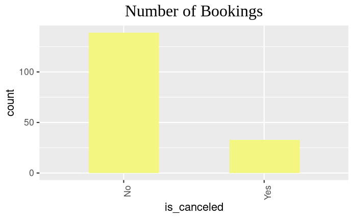

```r
# Plotting the chart
ggplot(cancelled_df, aes(x = is_canceled, y = count)) +
  geom_col(
    stat="identity", width=0.5, fill = "#F3F781"
  ) +
  labs(
    title = "Number of Bookings",
    x = "is_canceled",
    y = "count"
  ) +
  theme(
    plot.title = element_text(hjust = 0.5, size=16, family="Times New Roman"),
    axis.text.x = element_text(angle = 90, hjust = 1)
  )
```

2. What was the booking ratio between resort hotel and city hotel?

```r
hoteltype_df <- hotel_df %>% group_by(hotel) %>%
  summarise(number_of_bookings=n(),
            .groups = 'drop')

hoteltype_df
```

| hotel | number_of_bookings |
| --- | --- |
| City Hotel | 69 |
| Resort Hotel | 103 |

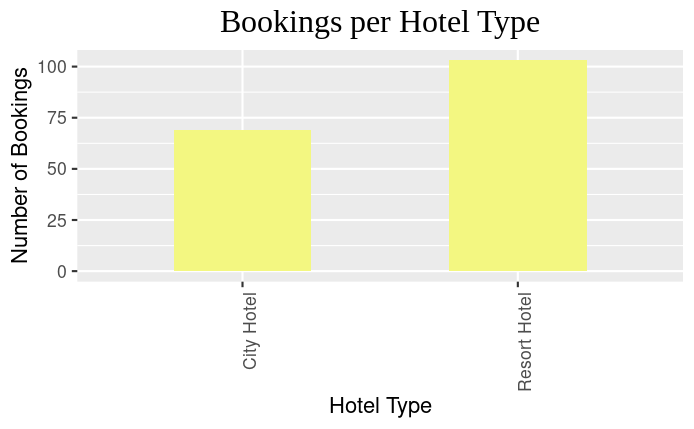

```r
# Plotting the chart
ggplot(hoteltype_df, aes(x = hotel, y = number_of_bookings)) +
  geom_col(
    stat="identity", width=0.5, fill = "#F3F781"
  ) +
  labs(
    title = "Bookings per Hotel Type",
    x = "Hotel Type",
    y = "Number of Bookings"
  ) +
  theme(
    plot.title = element_text(hjust = 0.5, size=16, family="Times New Roman"),
    axis.text.x = element_text(angle = 90, hjust = 1)
  )
```

```r
yearlybookings_df <- hotel_df %>% group_by(arrival_date_year) %>%
  summarise(number_of_bookings=n(),
            .groups = 'drop')

yearlybookings_df
```

| arrival_date_year | number_of_bookings |
| --- | --- |
| 2015 | 32 |
| 2016 | 78 |
| 2017 | 62 |

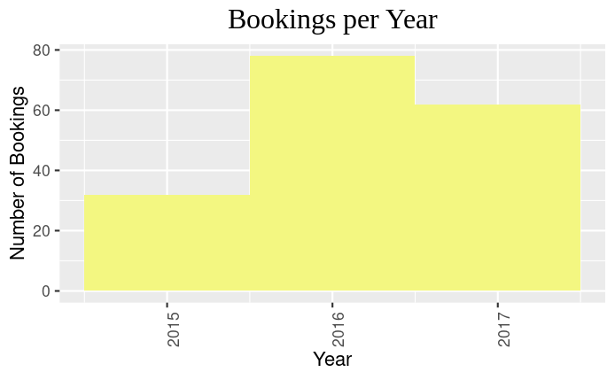

```r
# Plotting the chart
ggplot(yearlybookings_df, aes(x = arrival_date_year, y = number_of_bookings)) +
  geom_col(
    stat="identity", width=1, fill = "#F3F781"
  ) +
  labs(
    title = "Bookings per Year",
    x = "Year",
    y = "Number of Bookings"
  ) +
  theme(
    plot.title = element_text(hjust = 0.5, size=16, family="Times New Roman"),
    axis.text.x = element_text(angle = 90, hjust = 1)
  )
```

4. Which were the most busiest months for hotels?

```r
monthlybookings_df <- hotel_df %>% group_by(arrival_date_month) %>%
  summarise(number_of_bookings=n(),
            .groups = 'drop')

monthlybookings_df
```

| arrival_date_month | number_of_bookings |
| --- | --- |
| April | 13 |
| August | 41 |
| December | 14 |
| February | 13 |
| January | 11 |
| July | 31 |
| June | 13 |
| March | 6 |
| May | 8 |
| November | 3 |

[output cut: 2 more lines]

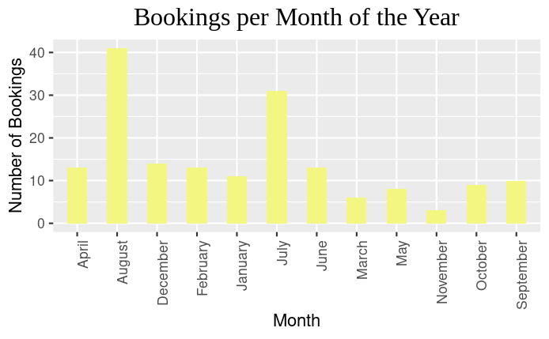

```r
# Plotting the chart
ggplot(monthlybookings_df, aes(x = arrival_date_month, y = number_of_bookings)) +
  geom_col(
    stat="identity", width=0.5, fill = "#F3F781"
  ) +
  labs(
    title = "Bookings per Month of the Year",
    x = "Month",
    y = "Number of Bookings"
  ) +
  theme(
    plot.title = element_text(hjust = 0.5, size=16, family="Times New Roman"),
    axis.text.x = element_text(angle = 90, hjust = 1)
  )
```

July and August were the busiest months for hotels.

5. From which top 3 countries did most guests come from?

```r
country_df <- hotel_df %>% group_by(country) %>%
  summarise(number_of_bookings=n(),
            .groups = 'drop')

country_df = country_df %>%
  arrange(desc(number_of_bookings))

top3countries = top_n(country_df, 3, number_of_bookings)

top3countries
```

| country | number_of_bookings |
| --- | --- |
| PRT | 90 |
| ESP | 21 |
| FRA | 16 |

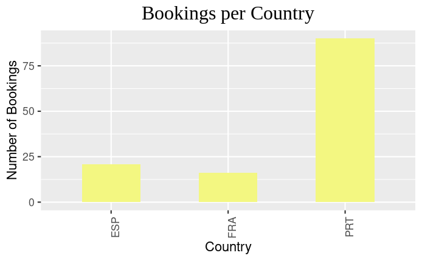

```r
# Plotting the chart
ggplot(top3countries, aes(x = country, y = number_of_bookings)) +
  geom_col(
    stat="identity", width=0.5, fill = "#F3F781"
  ) +
  labs(
    title = "Bookings per Country",
    x = "Country",
    y = "Number of Bookings"
  ) +
  theme(
    plot.title = element_text(hjust = 0.5, size=16, family="Times New Roman"),
    axis.text.x = element_text(angle = 90, hjust = 1)
  )
```

6.a) How long do most people stay in hotels?

```r
hotel_df2 = hotel_df %>%
  mutate(stays_in_nights = stays_in_weekend_nights +  stays_in_week_nights)
```

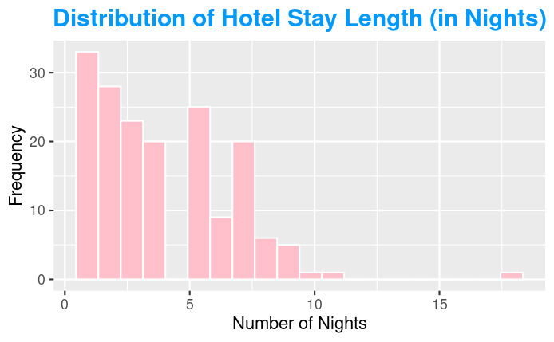

```r
ggplot(hotel_df2, aes(x = stays_in_nights)) +
  geom_histogram(
    bins=20, fill = "pink", color = "white"
  ) +
  labs(
    title = "Distribution of Hotel Stay Length (in Nights)",
    x = "Number of Nights",
    y ="Frequency"
  ) +
  theme(
    plot.title = element_text(color = "#0099f9", size = 15, face = "bold", hjust = 0.5),
  )
```

2. By city and resort? Separate the data by hotel

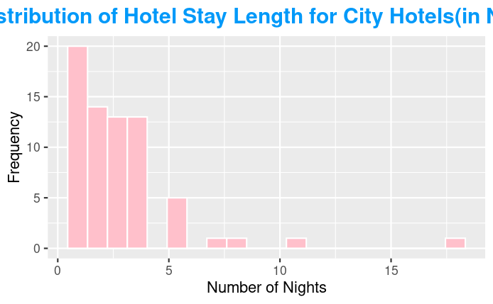

```r
city_hotel = filter(hotel_df2, hotel == 'City Hotel')
resort_hotel = filter(hotel_df2, hotel == 'Resort Hotel')

ggplot(city_hotel, aes(x = stays_in_nights)) +
  geom_histogram(
    bins=20, fill = "pink", color = "white"
  ) +
  labs(
    title = "Distribution of Hotel Stay Length for City Hotels(in Nights)",
    x = "Number of Nights",
    y ="Frequency"
  ) +
  theme(
    plot.title = element_text(color = "#0099f9", size = 15, face = "bold", hjust = 0.5),
  )
```

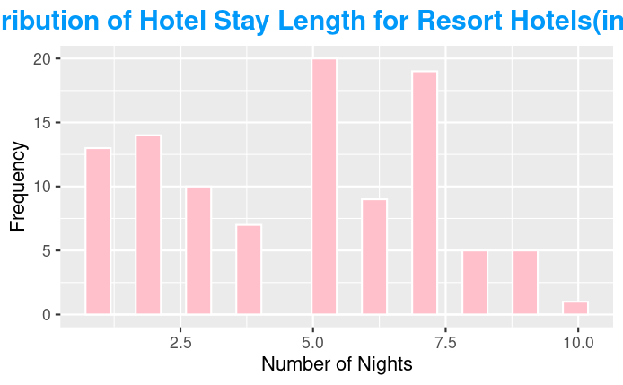

```r
ggplot(resort_hotel, aes(x = stays_in_nights)) +
  geom_histogram(
    bins=20, fill = "pink", color = "white"
  ) +
  labs(
    title = "Distribution of Hotel Stay Length for Resort Hotels(in Nights)",
    x = "Number of Nights",
    y ="Frequency"
  ) +
  theme(
    plot.title = element_text(color = "#0099f9", size = 15, face = "bold", hjust = 0.5),
  )
```

## 6. Follow up questions

a). Did we have the right data?

We had sufficient data to answer most of the questions posed.

b). Do we need other data to answer our question?

c). Did we have the right question?

Yes we had the right question.